# Proteome_analysis

## Подготовка данных

```r
raw_data <- fread("raw_data.csv")
raw_data$Total_score <- as.numeric(sapply(raw_data$Total_score, function(x) sub(",", ".", x)))
raw_data$Unused_score <- as.numeric(sapply(raw_data$Unused_score, function(x) sub(",", ".", x)))
raw_data$`% Cov` <- as.numeric(sapply(raw_data$`% Cov`, function(x) sub(",", ".", x)))
raw_data$`% Cov (95)` <- as.numeric(sapply(raw_data$`% Cov (95)`, function(x) sub(",", ".", x)))
raw_data$Accession <- sapply(raw_data$Accession, function(x) unlist(strsplit(x, "|", fixed = T))[2])
setnames(raw_data, "Accession", "Uniprot")
#Удаляем белки с unused score < 1.3
raw_data <- raw_data[raw_data$Unused_score >= 1.3]
```

## Аннотация по Gene Ontology

```r
# define biomart object
mart <- useMart(biomart = "ensembl", dataset = "hsapiens_gene_ensembl")

# query biomart
BM_out <- getBM(attributes = c("name_1006", "namespace_1003", "hgnc_symbol", "uniprotswissprot"),
                 filters = "uniprotswissprot",
                values = raw_data$Uniprot,
                mart = mart,
                uniqueRows = TRUE)

#Удаляем неинформативные GO
BM_out <- BM_out[BM_out$name_1006 != "molecular_function" &
                  BM_out$name_1006 != "cellular_component" &
                   BM_out$name_1006 != "biological_process" ,]

BM_out <- as.data.table(BM_out)

mol_function <- BM_out[namespace_1003 == "molecular_function", .(uniprotswissprot, hgnc_symbol, name_1006)]
mol_function[, mol_function := .(list(name_1006)), by=uniprotswissprot]
mol_function[, name_1006 := NULL]
mol_function <- mol_function[!duplicated(mol_function)]

cell_component <- BM_out[namespace_1003 == "cellular_component", .(uniprotswissprot, hgnc_symbol, name_1006)]
cell_component[, cell_component := .(list(name_1006)), by=uniprotswissprot]
cell_component[, name_1006 := NULL]
cell_component <- cell_component[!duplicated(cell_component)]

bio_process <- BM_out[namespace_1003 == "biological_process", .(uniprotswissprot, hgnc_symbol, name_1006)]
bio_process[, bio_process := .(list(name_1006)), by=uniprotswissprot]
bio_process[, name_1006 := NULL]
bio_process <- bio_process[!duplicated(bio_process)]

GO_data <- merge(mol_function, cell_component)
GO_data <- merge(GO_data, bio_process)

setnames(GO_data, "uniprotswissprot", "Uniprot")

final_data <- merge(raw_data, GO_data, by = "Uniprot")

rm(BM_out, mol_function, cell_component, bio_process, GO_data, raw_data)
```

Посмотрим, какие группы белков и сколько их там у нас реально есть

```r
prot_num <- final_data[, .N , by =. (Cell_line, Treatment, Compartment, Proteome_type)]
print(prot_num[order(N, decreasing = T)])
```

```
##     Cell_line Treatment Compartment Proteome_type   N
##  1:       Im9         K           N         PSMA3 299
##  2:  RPMI8226        FC           N     UBD_HDAC6 215
##  3:       Im9        FC           N     UBD_HDAC6 215
##  4:       Im9        FC           N         PSMA3 184
##  5:       Im9         K           C         PSMA3 132
##  6:  RPMI8226        FC           N         PSMA3  76
##  7:  RPMI8226         K           N     UBD_HDAC6  55
##  8:       Im9         K           N     UBD_HDAC6  55
##  9:       Im9        FC           C         PSMA3  50
## 10:  RPMI8226         K           N         PSMA3  48
## 11:  RPMI8226         K           C         PSMA3  44
## 12:       Im9        RB           N         PSMA3  39
## 13:  RPMI8226        FC           C         PSMA3  33
## 14:       Im9       CmB           N         PSMA3  33
## 15:  RPMI8226        RB           C         PSMA3  31
## 16:       Im9       CmB           C         PSMA3  29
## 17:  RPMI8226        FC           C     UBD_HDAC6  27
## 18:       Im9        FC           C     UBD_HDAC6  27
## 19:       Im9        RB           C         PSMA3  26
## 20:  RPMI8226       CmC           C         PSMA3  20
## 21:  RPMI8226        RB           N         PSMA3  16
## 22:  RPMI8226         K           C     UBD_HDAC6   7
## 23:       Im9         K           C     UBD_HDAC6   7
## 24:  RPMI8226       CmC           N         PSMA3   5
##     Cell_line Treatment Compartment Proteome_type   N
```

Прикольно, видим, что из ядра настрелялось больше всего белков! Хотят тут может быть явный batch-эффект, когда от методики приготовления состав более зависим, чем от обработки. Надо подумать об этом

## RPMI vs IM9

Сравним RPMI и IM9 в контроле по списку белков.

```r
final_data[Treatment == "K", .N , by =. (Cell_line, Proteome_type)]
```

```
##    Cell_line Proteome_type   N
## 1:       Im9         PSMA3 431
## 2:  RPMI8226         PSMA3  92
## 3:  RPMI8226     UBD_HDAC6  62
## 4:       Im9     UBD_HDAC6  62
```

Что видим, что где-то хорошо прошел эксперимент, а где-то явно так себе. Но мы не будем отчаиваться, будем делать как есть!

```r
#Разбили по разным датасетам по клеточной линии
PSMA3 <- final_data[Proteome_type == "PSMA3", ]
PSMA3 <- PSMA3[Treatment == "K", ]

UBD <- final_data[Proteome_type == "UBD_HDAC6", ]
UBD <- UBD[Treatment == "K", ]
```

### PSMA3 пробы

#### Найдем общие белки для RPMI и IM9

```r
common_PSMA3 <- intersect(PSMA3[Cell_line == "Im9", "Uniprot"], PSMA3[Cell_line == "RPMI8226", "Uniprot"]) #Пересекли
common_PSMA3 <- common_PSMA3[!duplicated(common_PSMA3)]
#Переведем идентификаторы Uniprot в NCBI gene symbols

common_PSMA3 <- getBM(attributes = c("hgnc_symbol","uniprotswissprot"),
                 filters = "uniprotswissprot",
                values = common_PSMA3,
                mart = mart,
                uniqueRows = TRUE)
common_PSMA3$hgnc_symbol
```

```
##  [1] "LANCL1"    "NDUFS3"    "MT-CO2"    "LMNA"      "HSPB1"
##  [6] "RPN1"      "ATP5F1B"   "NPM1"      "TUBB"      "HSP90AB1"
## [11] "VIM"       "RPSA"      "HNRNPA1"   "HSPD1"     "HSPA5"
## [16] "HSPA8"     "PABPC1"    "PKM"       "CBR1"      "DDX5"
## [21] "LMNB1"     "VDAC1"     "HNRNPA2B1" "ATP5F1A"   "PSMA1"
## [26] "PSMA3"     "EEF1G"     "HNRNPH1"   "PHB"       "HSPA9"
## [31] "RPS19"     "DDOST"     "HADHA"     "MATR3"     "RPS5"
## [36] "PRRC2A"    "CCT8"      "HNRNPM"    "EIF3B"     "RAB10"
## [41] "RPS3A"     "HNRNPK"    "HIST1H4I"  "HIST1H4A"  "HIST1H4B"
## [46] "HIST1H4C"  "HIST1H4K"  "HIST1H4J"  "HIST1H4L"  "HIST1H4D"
## [51] "HIST1H4E"  "HIST1H4F"  "HIST1H4H"  "HIST4H4"   "HIST2H4A"
## [56] "HIST2H4B"  "ACTG1"     "HBA2"      "HBA1"      "SRSF3"
## [61] "HNRNPU"    "SRSF1"     "LMAN2"     "UBAP2"     "HIST2H3D"
## [66] "HIST2H3C"  "HIST2H3A"  "MTDH"      "CCAR2"     "EIF3C"
## [71] "HNRNPAB"   "SRRT"
```

Итого получили для RPMI и IM9 линий 72 общих белков

Что нам говорит msigdb для этих белков: В топе функций у нас - GO_RNA_BINDING  
GO_POLY_A_RNA_BINDING  
GO_CHROMATIN_SILENCING_AT_RDNA  
GO_NEGATIVE_REGULATION_OF_MEGAKARYOCYTE_DIFFERENTIATION  
REACTOME_RNA_POL_I_PROMOTER_OPENING  
GO_GENE_SILENCING_BY_RNA  
GO_NEGATIVE_REGULATION_OF_HEMATOPOIETIC_PROGENITOR_CELL_DIFFERENTIATION  
REACTOME_MEIOSIS  
GO_REGULATION_OF_MEGAKARYOCYTE_DIFFERENTIATION  
GO_TELOMERE_CAPPING

См. файл приложенный msig_all_PSMA3_common.xlsx - там есть и FDR p-value, эти функции белков достоверны.

По hallmark genesets - похоже, что обогащение на фракцию генов - таргетов MYC См. файл приложенный msig_hallmark_PSMA3_common.xlsx

Гистограммки по GO

```r
GO_PSMA_common <- merge(common_PSMA3, final_data[, .(hgnc_symbol, mol_function, bio_process, cell_component)], by = "hgnc_symbol",  all.x= T)
GO_PSMA_common <- GO_PSMA_common[!duplicated(GO_PSMA_common), ]
mf_table <- table(unlist(GO_PSMA_common$mol_function))
bp_table <- table(unlist(GO_PSMA_common$bio_process))
cc_table <- table(unlist(GO_PSMA_common$cell_component))
```

Гистограммка по mol_function

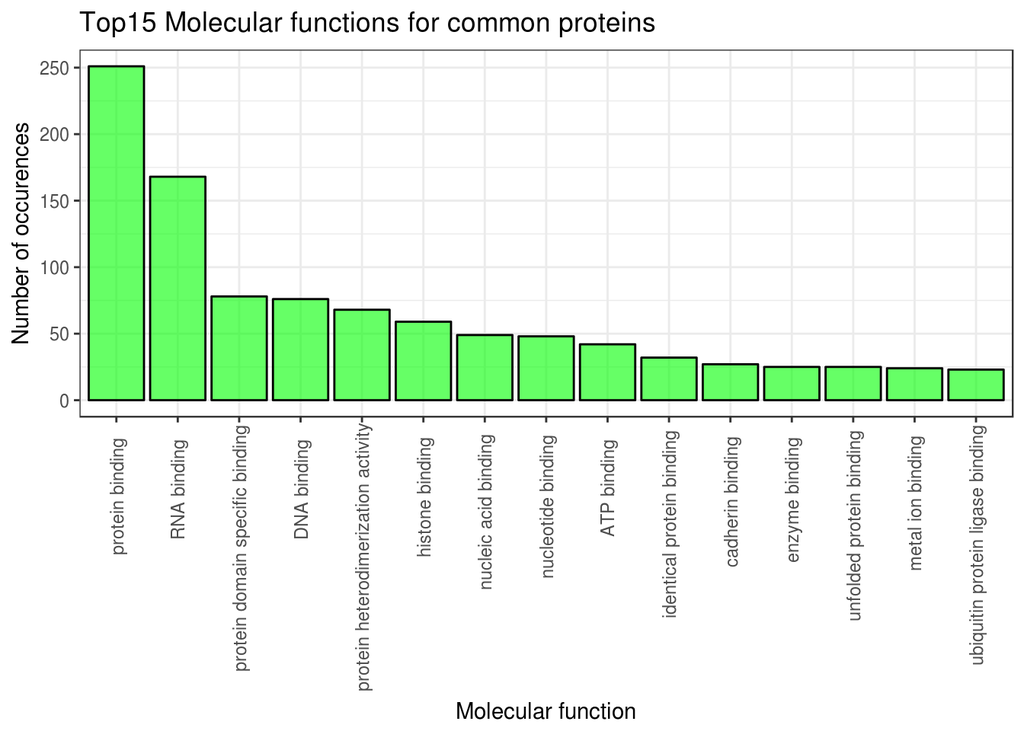

Гистограммка по biological process - не информативна нифига, забей на нее

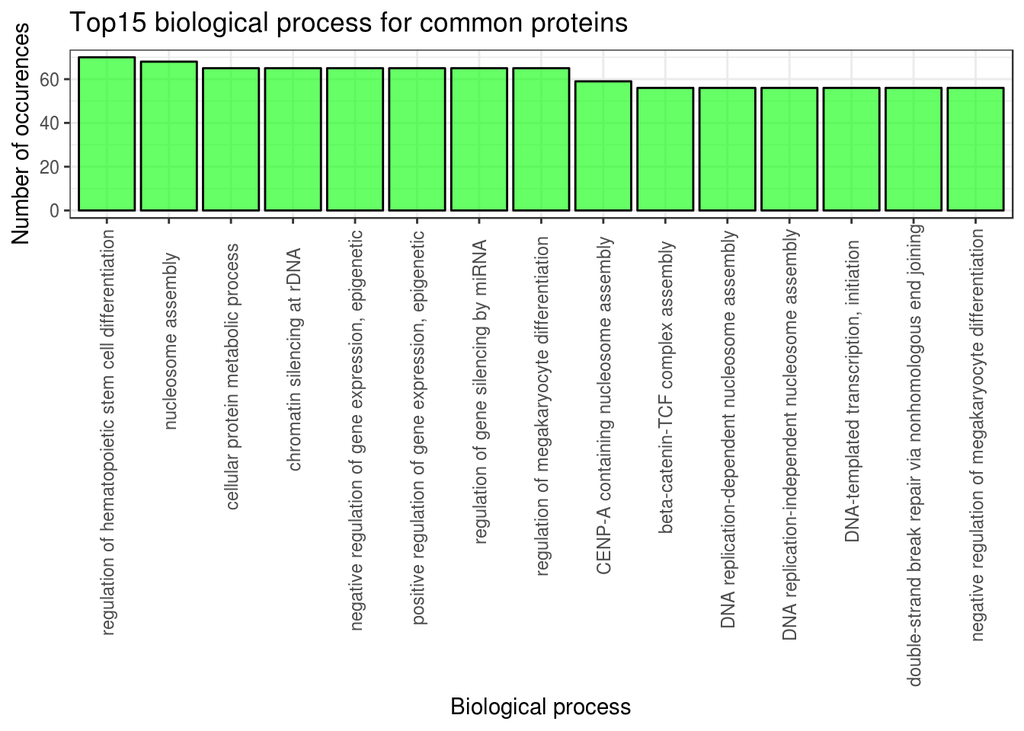

Гистограммка по cell_component

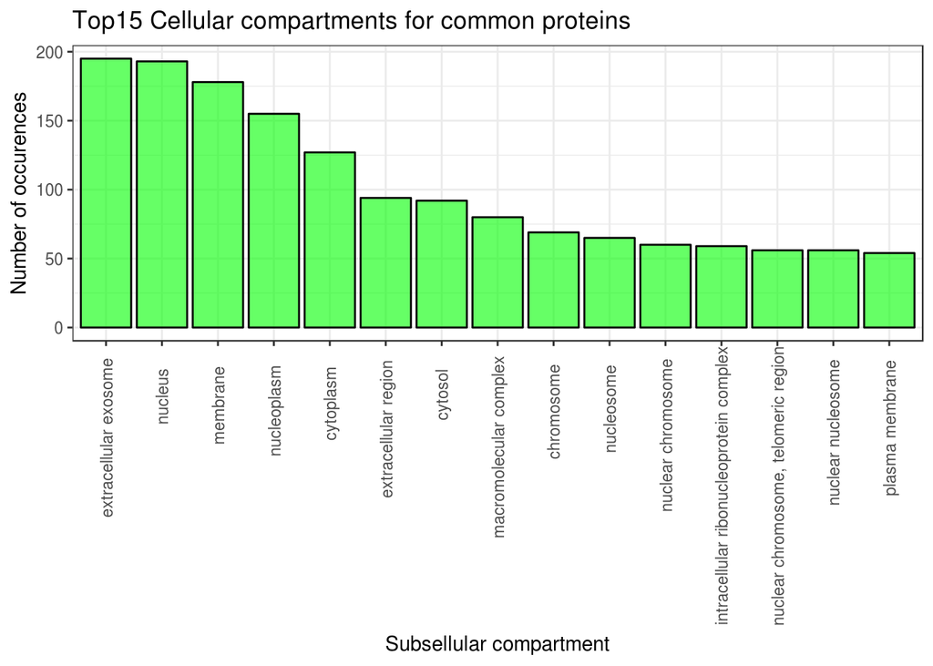

#### Найдем уникальные белки для RPMI и IM9

Для RPMI линии:

```r
unique_RPMI_PSMA3 <- is.element(PSMA3[Cell_line == "RPMI8226", hgnc_symbol], common_PSMA3$hgnc_symbol)
unique_RPMI_PSMA3 <- PSMA3[Cell_line == "RPMI8226", hgnc_symbol][-unique_RPMI_PSMA3]
unique_RPMI_PSMA3 <- unique_RPMI_PSMA3[!duplicated(unique_RPMI_PSMA3)]
unique_RPMI_PSMA3
```

```
##  [1] "UNC13B"    "PSMA7"     "LANCL1"    "NDUFS3"    "WNT11"
##  [6] "MT-CO2"    "IGLV1-51"  "LMNA"      "ALB"       "HSPB1"
## [11] "RPN1"      "ATP5F1B"   "NPM1"      "TUBB"      "HSP90AB1"
## [16] "VIM"       "RPSA"      "HNRNPA1"   "HSPD1"     "HSPA5"
## [21] "HSPA8"     "PABPC1"    "PKM"       "CBR1"      "HIST1H1C"
## [26] "DDX5"      "LMNB1"     "VDAC1"     "HNRNPA2B1" "PPIB"
## [31] "RPS3"      "EEF1B2"    "ATP5F1A"   "PSMA1"     "PSMA3"
## [36] "HMGB2"     "EEF1G"     "HNRNPH1"   "PHB"       "HSPA9"
## [41] "RPS19"     "DDOST"     "HADHA"     "MATR3"     "RPS5"
## [46] "PRRC2A"    "CCT8"      "HNRNPM"    "HNRNPF"    "EIF3B"
## [51] "RAB10"     "RPS3A"     "HNRNPK"    "HIST1H4I"  "ACTG1"
## [56] "TUBA1B"    "HBA2"      "SRSF3"     "HNRNPU"    "ATP7A"
## [61] "SRSF1"     "LMAN2"     "ATXN7L3"   "SF1"       "TUBB8"
## [66] "UBAP2"     "HIST2H3D"  "H2AFV"     "MTDH"      "HRNR"
## [71] "CCAR2"     "SCARB1"    "WRNIP1"    "EIF3C"     "HNRNPAB"
## [76] "RBM4"      "SRRT"      "NHP2"      "ZNF451"    "PRRC2C"
```

Что это за ребята? Смотри файл - msig_all_PSMA3_RPMI_unique.xlsx

Гистограммки по GO

```r
unique_RPMI_PSMA3 <- getBM(attributes = c("hgnc_symbol","uniprotswissprot"),
                 filters = "hgnc_symbol",
                values = common_PSMA3,
                mart = mart,
                uniqueRows = TRUE)


GO_unique_RPMI_PSMA3 <- merge(unique_RPMI_PSMA3, final_data[, .(hgnc_symbol, mol_function, bio_process, cell_component)], by = "hgnc_symbol",  all.x = T)
GO_unique_RPMI_PSMA3 <- GO_unique_RPMI_PSMA3[!duplicated(GO_unique_RPMI_PSMA3), ]
mf_table <- table(unlist(GO_unique_RPMI_PSMA3$mol_function))
bp_table <- table(unlist(GO_unique_RPMI_PSMA3$bio_process))
cc_table <- table(unlist(GO_unique_RPMI_PSMA3$cell_component))
```

Гистограммка по mol_function

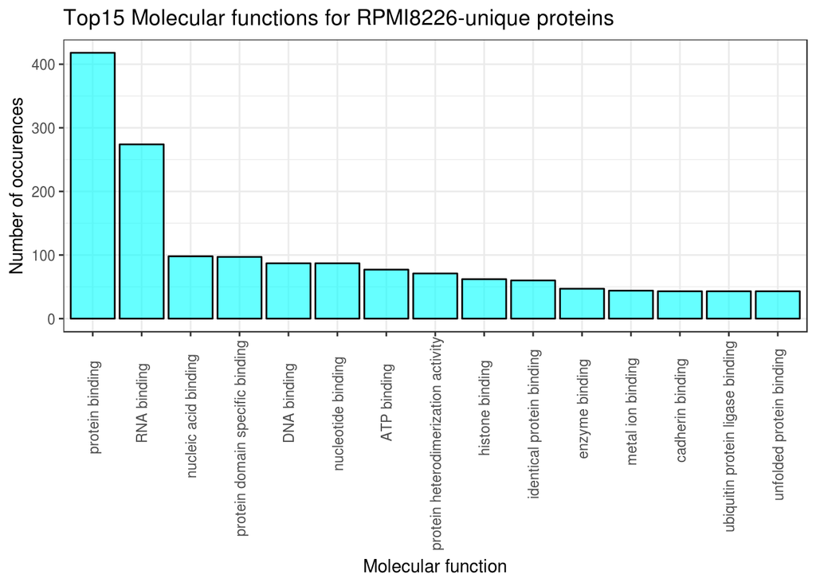

Гистограммка по biological process - забей, не шибко информативная

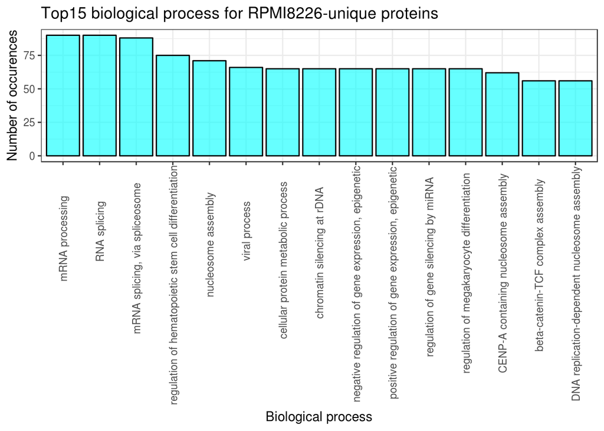

Гистограммка по cell_component

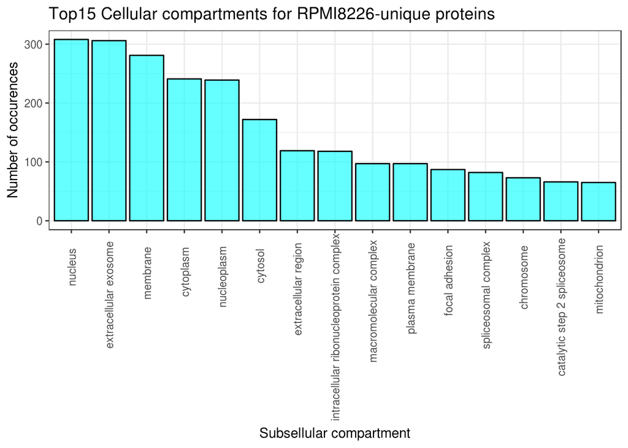

Для IM9 линии:

```r
unique_IM9_PSMA3 <- is.element(PSMA3[Cell_line == "Im9", hgnc_symbol], common_PSMA3$hgnc_symbol)
unique_IM9_PSMA3 <- PSMA3[Cell_line == "Im9", hgnc_symbol][-unique_IM9_PSMA3]
unique_IM9_PSMA3 <- unique_IM9_PSMA3[!duplicated(unique_IM9_PSMA3)]
unique_IM9_PSMA3
```

```
##   [1] "MYO1G"     "AIP"       "PGRMC1"    "DDX3X"     "COPE"
##   [6] "SCAMP3"    "UQCRQ"     "HNRNPDL"   "XPO1"      "PGRMC2"
##  [11] "DHX15"     "CYB5B"     "PHGDH"     "HNRNPR"    "NDUFA2"
##  [16] "NUDT21"    "LANCL1"    "IDH3B"     "PLIN3"     "LPXN"
##  [21] "CTNND1"    "NDUFS2"    "H2AFY"     "SEC22B"    "PSIP1"
##  [26] "NDUFS3"    "SF3B1"     "SNRNP200"  "NUP155"    "RSL1D1"
##  [31] "MTA2"      "TOMM70"    "PRPF6"     "LETM1"     "AP2A1"
##  [36] "AIFM1"     "NDUFB10"   "TOMM40"    "CYB5A"     "GLUD1"
##  [41] "MT-CO2"    "PGK1"      "HLA-A"     "HLA-DRA"   "LMNA"
##  [46] "TFRC"      "VTN"       "HLA-DPB1"  "HSPB1"     "RPN1"
##  [51] "RPN2"      "GNAI2"     "ATP1A1"    "SLC25A5"   "RPLP1"
##  [56] "ATP5F1B"   "ENO1"      "FCER2"     "NPM1"      "TUBB"
##  [61] "EPRS"      "HSP90AA1"  "HNRNPC"    "ANXA6"     "SLC3A2"
##  [66] "HSP90AB1"  "CYC1"      "PTPRC"     "SNRPB2"    "SNRNP70"
##  [71] "VIM"       "RPSA"      "CD48"      "HNRNPA1"   "PARP1"
```

[output cut: 60 more lines]

Для линии IM9 нашлось 373 уникальных белков. Их тут гораздо больше! Что это за ребята? Смотри файл - msig_all_PSMA3_IM9_unique.xlsx Там в основном за РНК-связывание топят тоже

Гистограммки по GO

```r
unique_IM9_PSMA3 <- getBM(attributes = c("hgnc_symbol","uniprotswissprot"),
                 filters = "hgnc_symbol",
                values = common_PSMA3,
                mart = mart,
                uniqueRows = TRUE)


GO_unique_IM9_PSMA3 <- merge(unique_IM9_PSMA3, final_data[, .(hgnc_symbol, mol_function, bio_process, cell_component)], by = "hgnc_symbol",  all.x = T)

GO_unique_IM9_PSMA3 <- GO_unique_IM9_PSMA3[!duplicated(GO_unique_IM9_PSMA3), ]
mf_table <- table(unlist(GO_unique_IM9_PSMA3$mol_function))
bp_table <- table(unlist(GO_unique_IM9_PSMA3$bio_process))
cc_table <- table(unlist(GO_unique_IM9_PSMA3$cell_component))
```

Гистограммка по mol_function

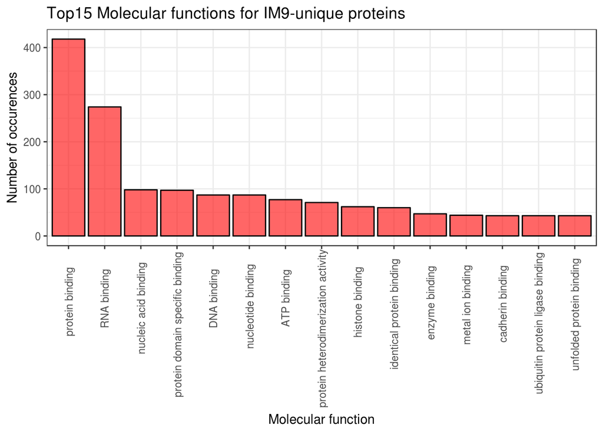

Гистограммка по biological process - чуть более интересная, но тоже ровная, ничего особо в ней классного

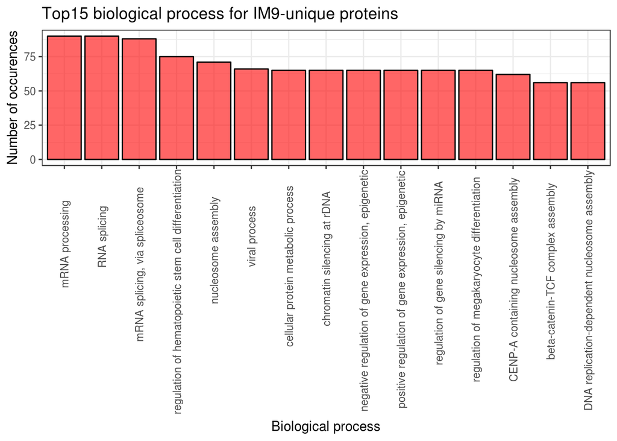

Гистограммка по cell_component

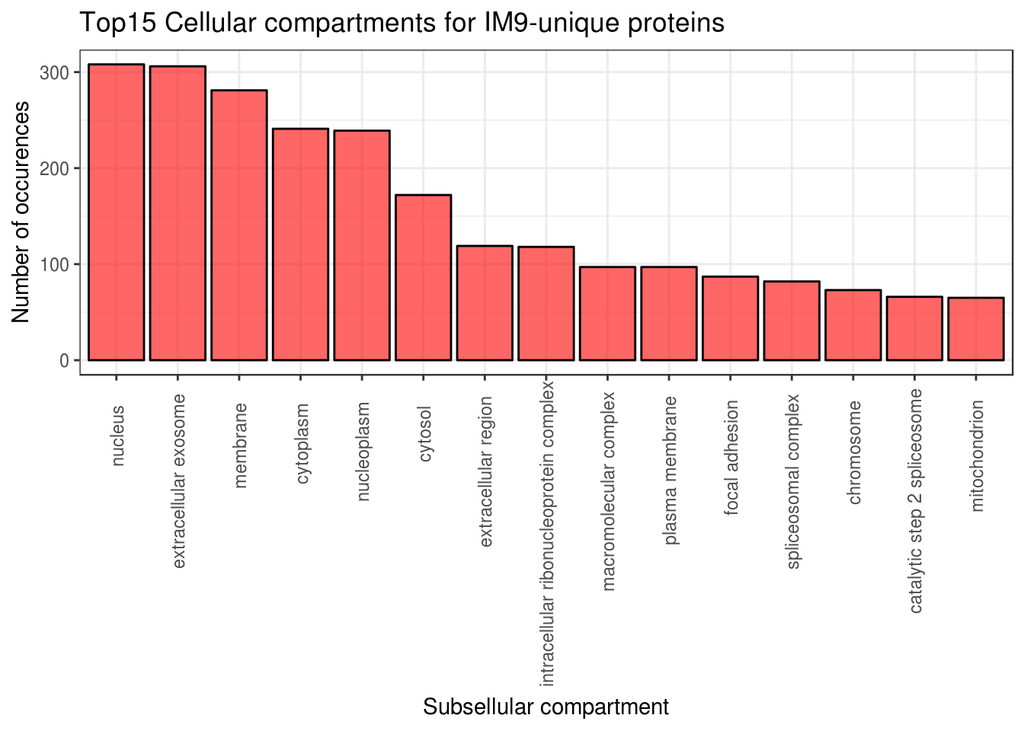

### Разница между линиями по UBD

#### Схожие белки

```r
common_UBD <- intersect(UBD[Cell_line == "Im9", Uniprot], UBD[Cell_line == "RPMI8226", Uniprot]) #Пересекли
common_UBD <- common_UBD[!duplicated(common_UBD)]
common_UBD <- as.data.table(common_UBD)
#Переведем идентификаторы Uniprot в NCBI gene symbols

common_UBD <- getBM(attributes = c("hgnc_symbol","uniprotswissprot"),
                 filters = "uniprotswissprot",
                values = common_UBD,
                mart = mart,
                uniqueRows = TRUE)
common_UBD$hgnc_symbol
```

```
##  [1] "NUDT21"    "SF3B1"     "GLUD1"     "MT-CO2"    "ATP5F1B"
##  [6] "NPM1"      "TUBB"      "HNRNPC"    "GSTP1"     "HNRNPA1"
## [11] "HSPD1"     "HSPA8"     "XRCC5"     "LCP1"      "HSP90B1"
## [16] "HNRNPL"    "DARS"      "RPS2"      "CBR1"      "LMNB1"
## [21] "FBL"       "HNRNPA2B1" "SFPQ"      "RPS3"      "PTBP1"
## [26] "EEF1G"     "HNRNPH1"   "LSP1"      "MYH9"      "RBMX"
## [31] "TUFM"      "HNRNPA3"   "COPA"      "RPS3A"     "RPL15"
## [36] "HNRNPK"    "RPS18"     "HIST1H4I"  "HIST1H4A"  "HIST1H4B"
## [41] "HIST1H4C"  "HIST1H4K"  "HIST1H4J"  "HIST1H4L"  "HIST1H4D"
## [46] "HIST1H4E"  "HIST1H4F"  "HIST1H4H"  "HIST4H4"   "HIST2H4A"
## [51] "HIST2H4B"  "TRA2B"     "ACTG1"     "PRKDC"     "SRSF3"
## [56] "CLTC"      "HNRNPU"    "SPTBN1"    "RPL6"      "SRSF1"
## [61] "DHX9"      "ILF3"      "DDX39B"    "NONO"      "SF3B3"
## [66] "TUBA1A"    "SND1"      "HRNR"      "HIST1H2AC" "HSD17B10"
## [71] "TUBA1C"    "DDX21"     "HDAC6"
```

Получилось 73 общих белков За что они отвечают - смотри в файле msig_all_UBD_common.xlsx

Здесь мы просто посмотрим диаграммки по GO

```r
GO_UBD_common <- merge(common_UBD, final_data[, .(hgnc_symbol, mol_function, bio_process, cell_component)], by = "hgnc_symbol",  all.x= T)
GO_UBD_common <- GO_UBD_common[!duplicated(GO_UBD_common), ]
mf_table <- table(unlist(GO_UBD_common$mol_function))
bp_table <- table(unlist(GO_UBD_common$bio_process))
cc_table <- table(unlist(GO_UBD_common$cell_component))
```

Гистограммка по mol_function

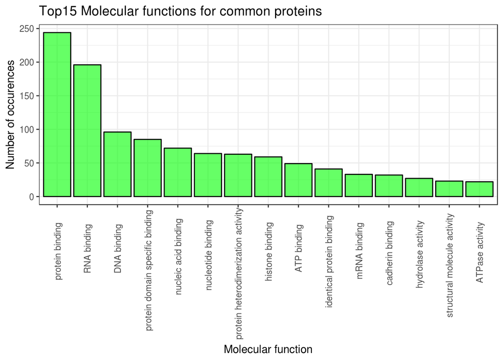

Гистограммка по biological process

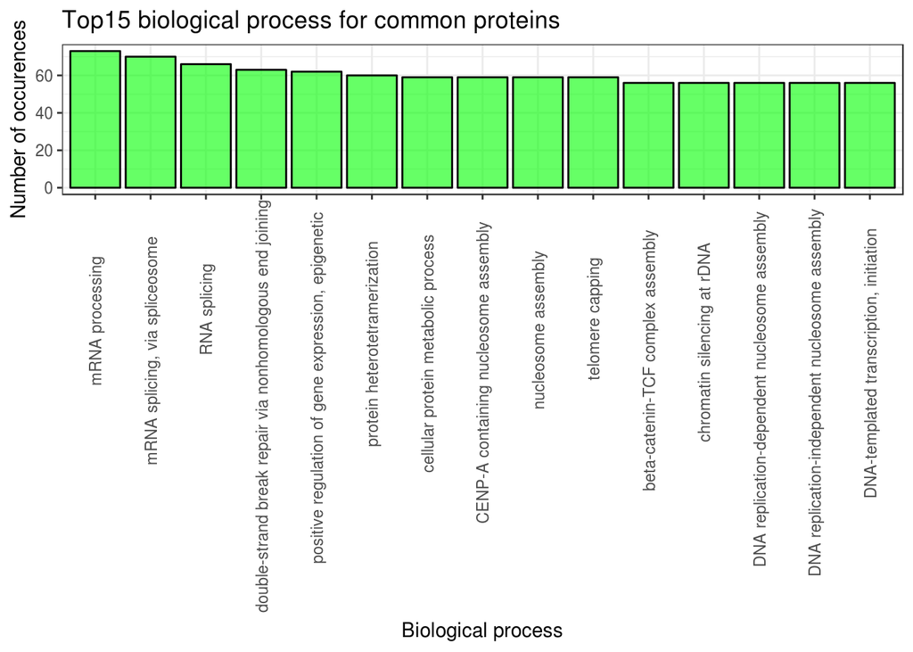

Гистограммка по cell_component

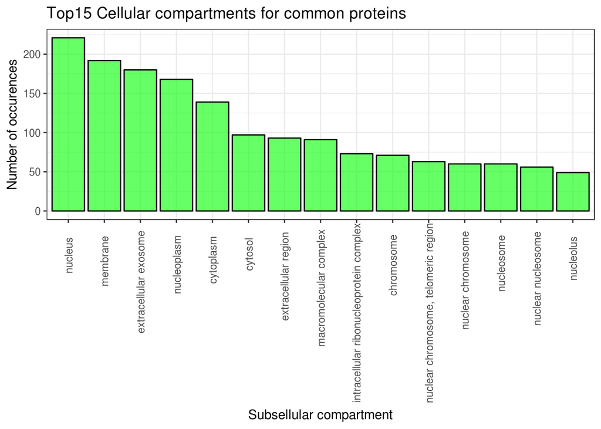

#### Найдем уникальные белки для RPMI и IM9

Для RPMI линии:

```r
unique_RPMI_UBD <- is.element(UBD[Cell_line == "RPMI8226", hgnc_symbol], common_UBD$hgnc_symbol)
unique_RPMI_UBD <- UBD[Cell_line == "RPMI8226", hgnc_symbol][-unique_RPMI_UBD]
unique_RPMI_UBD <- unique_RPMI_UBD[!duplicated(unique_RPMI_UBD)]
unique_RPMI_UBD
```

```
##  [1] "SF3B1"     "GLUD1"     "MT-CO2"    "ATP5F1B"   "NPM1"
##  [6] "TUBB"      "HNRNPC"    "GSTP1"     "HNRNPA1"   "HSPD1"
## [11] "HSPA8"     "XRCC5"     "LCP1"      "HSP90B1"   "HNRNPL"
## [16] "DARS"      "RPS2"      "CBR1"      "LMNB1"     "FBL"
## [21] "HNRNPA2B1" "SFPQ"      "RPS3"      "PTBP1"     "EEF1G"
## [26] "HNRNPH1"   "LSP1"      "MYH9"      "RBMX"      "TUFM"
## [31] "HNRNPA3"   "COPA"      "RPS3A"     "RPL15"     "HNRNPK"
## [36] "RPS18"     "HIST1H4I"  "TRA2B"     "ACTG1"     "PRKDC"
## [41] "SRSF3"     "CLTC"      "HNRNPU"    "SPTBN1"    "RPL6"
## [46] "SRSF1"     "DHX9"      "ILF3"      "DDX39B"    "NONO"
## [51] "SF3B3"     "TUBA1A"    "SND1"      "HRNR"      "HIST1H2AC"
## [56] "HSD17B10"  "TUBA1C"    "DDX21"     "HDAC6"
```

Для линии RPMI нашлось 59 уникальных белков

Гистограммки по GO

```r
unique_RPMI_UBD <- getBM(attributes = c("hgnc_symbol","uniprotswissprot"),
                 filters = "hgnc_symbol",
                values = common_UBD,
                mart = mart,
                uniqueRows = TRUE)


GO_unique_RPMI_UBD <- merge(unique_RPMI_UBD, final_data[, .(hgnc_symbol, mol_function, bio_process, cell_component)], by = "hgnc_symbol",  all.x = T)

GO_unique_RPMI_UBD <- GO_unique_RPMI_UBD[!duplicated(GO_unique_RPMI_UBD), ]
mf_table <- table(unlist(GO_unique_RPMI_UBD$mol_function))
bp_table <- table(unlist(GO_unique_RPMI_UBD$bio_process))
cc_table <- table(unlist(GO_unique_RPMI_UBD$cell_component))
```

Гистограммка по mol_function

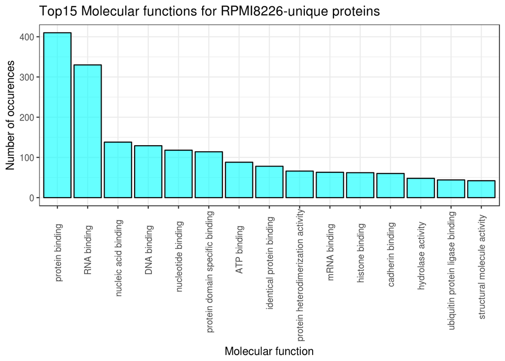

Гистограммка по biological process

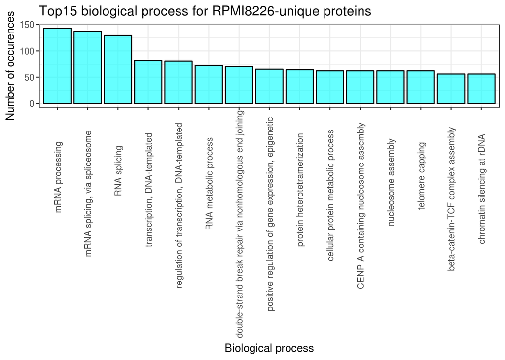

Гистограммка по cell_component

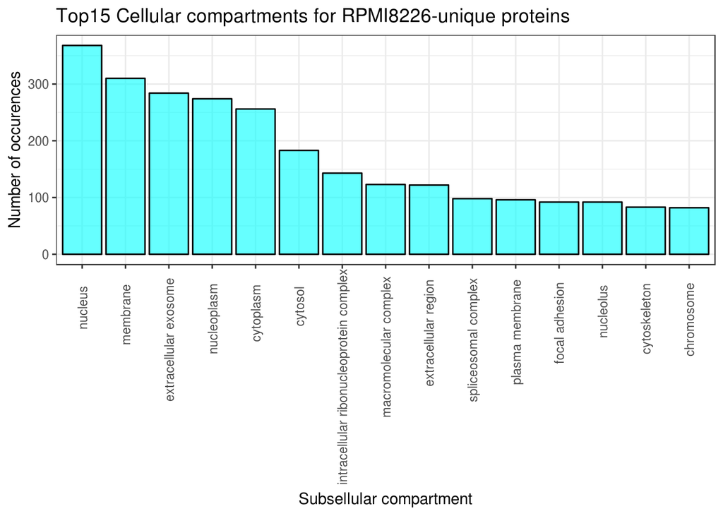

Для IM9 линии:

```r
unique_IM9_UBD <- is.element(UBD[Cell_line == "Im9", hgnc_symbol], common_UBD$hgnc_symbol)
unique_IM9_UBD <- UBD[Cell_line == "Im9", hgnc_symbol][-unique_IM9_UBD]
unique_IM9_UBD
```

```
##  [1] "SF3B1"     "GLUD1"     "MT-CO2"    "ATP5F1B"   "NPM1"
##  [6] "TUBB"      "HNRNPC"    "GSTP1"     "HNRNPA1"   "HSPD1"
## [11] "HSPA8"     "XRCC5"     "LCP1"      "HSP90B1"   "HNRNPL"
## [16] "DARS"      "RPS2"      "CBR1"      "LMNB1"     "FBL"
## [21] "HNRNPA2B1" "SFPQ"      "RPS3"      "PTBP1"     "EEF1G"
## [26] "HNRNPH1"   "LSP1"      "MYH9"      "RBMX"      "TUFM"
## [31] "HNRNPA3"   "COPA"      "RPS3A"     "RPL15"     "HNRNPK"
## [36] "RPS18"     "HIST1H4I"  "TRA2B"     "ACTG1"     "ACTG1"
## [41] "PRKDC"     "SRSF3"     "CLTC"      "HNRNPU"    "SPTBN1"
## [46] "RPL6"      "SRSF1"     "DHX9"      "ILF3"      "DDX39B"
## [51] "NONO"      "SF3B3"     "TUBA1A"    "SND1"      "HRNR"
## [56] "HIST1H2AC" "HSD17B10"  "TUBA1C"    "DDX21"     "HDAC6"
## [61] "HDAC6"
```

Для линии IM9 нашлось 61 уникальных белков

Гистограммки по GO

```r
unique_IM9_UBD <- getBM(attributes = c("hgnc_symbol","uniprotswissprot"),
                 filters = "hgnc_symbol",
                values = common_UBD,
                mart = mart,
                uniqueRows = TRUE)


GO_unique_IM9_UBD <- merge(unique_IM9_UBD, final_data[, .(hgnc_symbol, mol_function, bio_process, cell_component)], by = "hgnc_symbol",  all.x = T)

GO_unique_IM9_UBD <- GO_unique_IM9_UBD[!duplicated(GO_unique_IM9_UBD), ]
mf_table <- table(unlist(GO_unique_IM9_UBD$mol_function))
bp_table <- table(unlist(GO_unique_IM9_UBD$bio_process))
cc_table <- table(unlist(GO_unique_IM9_UBD$cell_component))
```

Гистограммка по mol_function

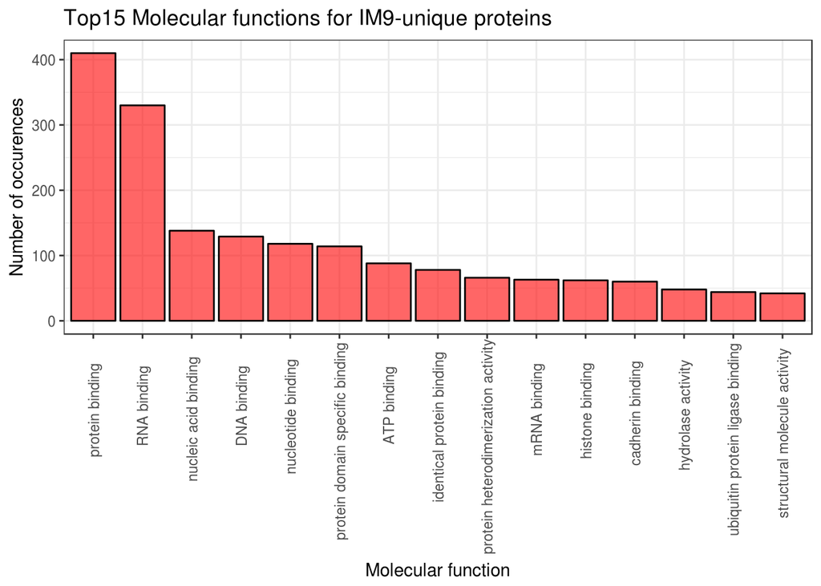

Гистограммка по biological process

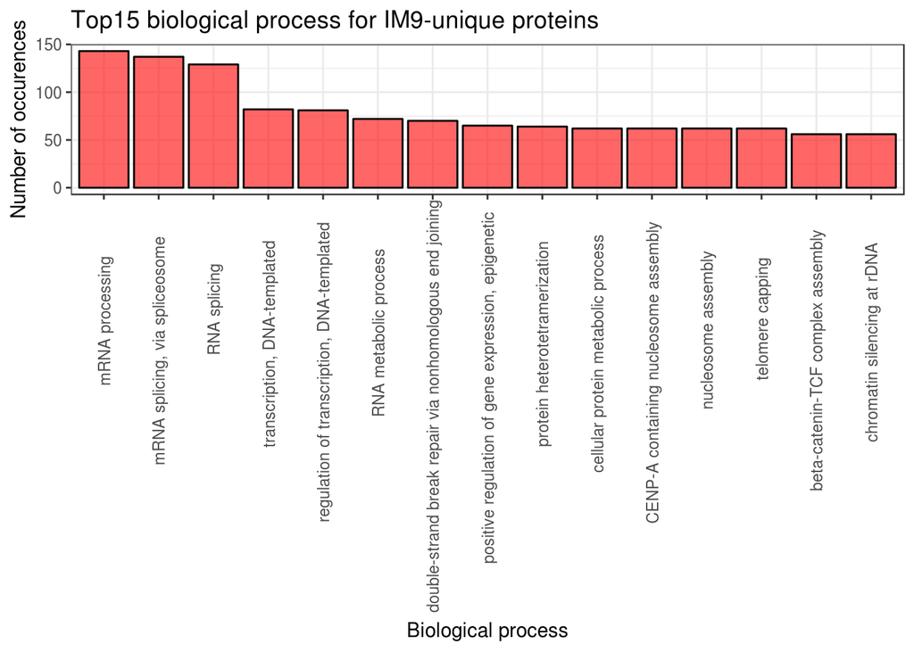

Гистограммка по cell_component

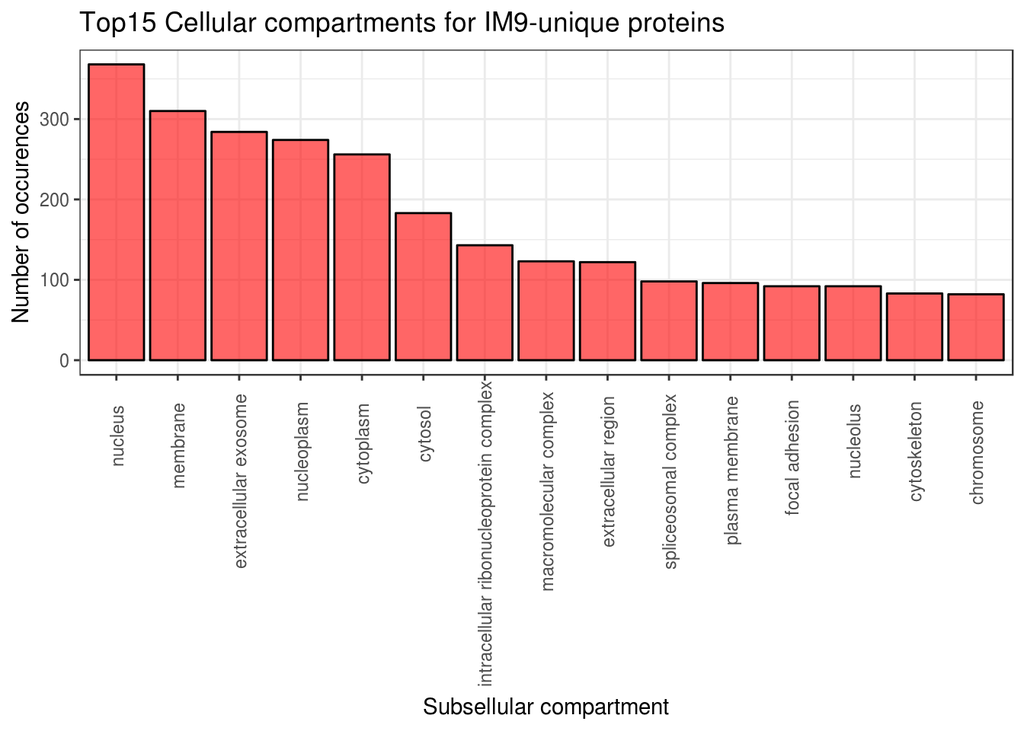

# Какие обработки были сделаны:

RB и FC есть для обеих линий - их сделать обработка против контроля